# RealniGA

## Realni Genetski Algoritam

- Realni genetski algoritam
- Ruletska selekcija
- Simetrično ukrštanje
- Primeri: sferna i Levijeva funkcija

**Postupak genetskog algoritma:** </br> START  
Inicijalizacija početne populacije  
Računanje funkcije prilagođenosti  
Ponavljati:

- Selekciju
- Ukrštanje
- Mutaciju
- Računanje funkcije prilagođenosti

DOK populacija ne iskonvergira  
STOP

# 1. Biblioteke

Prvo je nophodno učitati python biblioteke

```python
%matplotlib inline

import random
import numpy as np
import matplotlib.pyplot as plt
import math

from mpl_toolkits import mplot3d

pi = 3.1415
```

# 2. Generisanje populacije

**Početna populacija**

GA započinjemo kreiranjem skupa jedinki koji se naziva populacijom. Svaka jedinka predstavlja potencijalno rešenje.

```python
def generate_inital_chromosomes(length, max, min, pop_size):
  return [ [random.uniform(min,max) for j in range(length)] for i in range(pop_size)]

def population_stats(costs):
  return costs[0], sum(costs)/len(costs)
```

# 3. Funkcije za rangiranje i **selekciju** jedinki

Jedinke se rangiraju (sortiraju) po vrednosti funkcije prilagođenosti funkcijom **rank_chromosomes**.</br> Implementirane su sledece vrste selekcija: prirodna i ruletska selekcija. </br> Prirodna selekcija je implementirana u funkciji **natural_selection**, pri čemu ostavljamo samo prvih *n_keep* jedinki.</br> Funkcija **roulette_selection** predstavlja ruletski tip selekcije.

```python
def rank_chromosomes(cost, chromosomes):
  costs = list(map(cost, chromosomes))
  ranked  = sorted( list(zip(chromosomes,costs)), key = lambda c:c[1])

  return list(zip(*ranked))

def natural_selection(chromosomes, n_keep):
  return chromosomes[:n_keep]

def roulette_selection(parents):

  pairs = []
  i = 0
  for i in range(0, len(parents), 2):

    weights=[];
    for i in range(len(parents)):
        weights.append((len(parents)-i)*random.random()) #za minimum
      #  weights.append((i+1)*random.random()) #za maksimum
    if (weights[0]>=weights[1]):
        maxInd1=0;
        maxInd2=1;
    else:
        maxInd1=1;
        maxInd2=0;

    for i in range(2,len(parents)):
        if weights[i]>weights[maxInd1]:
            maxInd2=maxInd1
            maxInd1=i
        elif weights[i]>weights[maxInd2]:
            maxInd2=1
    pairs.append([parents[maxInd1], parents[maxInd2]])

  return pairs
```

# 4. Ukrštanje

a, b - roditelji </br> y1, y2 - potomci </br> (a, b) -> (y1, y2) </br> **Simetrično ukrštanje** </br> y1 = r *a + (1 - r)* b</br> y2 = (1 - r) *a + r* b,</br> gde je r slučanjo odabrani broj u intervalu (0, 1).

```python
def crossover(pairs):

  children = []

  for a,b in pairs:

    r=random.random()
    y1=[]
    y2=[]
    for i in range(0,len(a)):
      y1.append(r * a[i] + (1 - r) * b[i])
      y2.append((1 - r) *  a[i] + r*b[i])
    children.append(y1)
    children.append(y2)


  return children
```

```python
crossover([[[-0.5, -0.5], [-7.04, -2.5]],[[-1.5, -1.05], [-9.04, -9.5]]])
```

```
[[-5.154896040859851, -1.9235156088256427],
 [-2.3851039591401486, -1.0764843911743573],
 [-8.49138762176067, -8.885175783007648],
 [-2.048612378239329, -1.6648242169923517]]
```

# 5. Mutacija

Mutacija predstavlja slučajnu promenu nekih gena određene jedinke. Kako deluje nad samo jednom jedinkom, mutacija je unarni operator koji kao rezultat daje izmenjenu jedinku. Mutacija se na svaku jedinku primenjuje sa nekom malom verovatnoćom. Ukoliko je verovatnoća mutacije premala, ili se uopšte ne primenjuje, može doći do preuranjene lokalne konvergencije. Ako je vrednost verovatnoće mutacije velika, genetski algoritam će se svesti na slučajnu pretragu što nema smisla.

```python
def mutation(chromosomes, mutation_rate,mutation_width):
  mutated_chromosomes = []
  for chromosome in chromosomes:
    y1=[]
    for i in range(0,len(chromosome)):
      if random.random() < mutation_rate:
        r=random.random()

        y1.append( chromosome[i] + mutation_width * 2 * (r - 0.5) )
      else:
        y1.append(chromosome[i])

    mutated_chromosomes.append(y1)
  return mutated_chromosomes
```

```python
mutation([[-0.23170627655571208, 2.8058402091757224], [-2.538231077587461, 0.14136977843141585]], 0.3,1)
```

```
[[-0.23170627655571208, 3.8035626232761612],
 [-2.538231077587461, 0.14136977843141585]]
```

# 6. Elitizam

Postoji mogućnost da se dobro rešenje dobijeno nakon mnogo iteracija izgubi zbog genetskih operatora mutacije ili selekcije. Zbog toga se javlja potreba da se najbolje jedinke zaštite od izmene ili eliminacije tokom evolutivnog procesa. Takav mehanizam se naziva **elitizam**.

```python
def elitis(chromosomes_old,chromosomes_new, elitis_rate, population_size):

  old_ind_size=int(np.round(population_size*elitis_rate))
  return chromosomes_old[:old_ind_size]+chromosomes_new[:(population_size-old_ind_size)]
```

# 7. Definicija funkcije

Definisaćemo funkciju kojoj tražimo optimum (minimum).

## Primer 1: Sfera funkcija

Kao prvi primer koristićemo sfernu funkciju koja se definiše na sledeći način

\begin{equation} f(x, y) = x^2 +y ^2 \\ \mbox{interval: } -10 < x, y < 10,\\ \mbox{minimum: } f(0,0) = 0 \end{equation}

## Primer 2: Levijeva funkcija

Kao drugi primer koristićemo Levijevu funkciju koja se definiše na sledeći način

\begin{equation} f(x, y) = sin^2 3πx + (x − 1)^2(1 + sin^2 3πy) + (y − 1)^2(1 + sin^2 2πy) \\ \mbox{interval: } -10 < x, y < 10,\\ \mbox{minimum: } f(1,1) = 0 \end{equation}

```python
def sphera_function(chromosome):
  x = chromosome[0]
  y = chromosome[1]

  tmp1 = math.pow(x, 2)
  tmp2 = math.pow(y, 2)


  return tmp1 + tmp2
```

```python
def levy_function(chromosome):
  x = chromosome[0]
  y = chromosome[1]

  tmp1 = math.pow(math.sin(3*pi*x), 2)
  tmp2 = math.pow((x - 1), 2) * (1 + math.pow(math.sin(3*pi*y), 2))
  tmp3 = math.pow((y - 1), 2) * (1 + math.pow(math.sin(2*pi*y), 2))

  return tmp1 + tmp2 + tmp3
```

# 7.1. 3D Prikaz funkcije

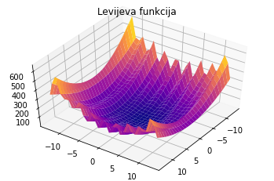

```python
def l_show(x, y):
  tmp1 = math.pow(math.sin(3*pi*x), 2)
  tmp2 = math.pow((x - 1), 2) * (1 + math.pow(math.sin(3*pi*y), 2))
  tmp3 = math.pow((y - 1), 2) * (1 + math.pow(math.sin(2*pi*y), 2))

  return tmp1 + tmp2 + tmp3

levy_vectorized = np.vectorize(l_show)

x = np.linspace(-13, 13, 30)
y = np.linspace(-13, 13, 30)

X, Y = np.meshgrid(x, y)
Z = levy_vectorized(X, Y)

ax = plt.axes(projection='3d')
ax.plot_surface(X, Y, Z, rstride=1, cstride=1,
                cmap='plasma', edgecolor='none')
ax.set_title('Levijeva funkcija');

ax.view_init(50, 35)
```

# 8. Main loop - sklopljen genetski algoritam

```python
def genetic(cost_func , extent, population_size, mutation_rate = 0.8,elitis_rate=0.1, chromosome_length = 2, precision = 13, max_iter = 100):

  min_val = extent[0]
  max_val = extent[1]


  avg_list = []
  best_list = []
  curr_best = 10000
  same_best_count = 0




  chromosomes = generate_inital_chromosomes(chromosome_length, max_val, min_val, population_size)

  for iter in range(max_iter):

    ranked_parents, costs = rank_chromosomes(cost_func, chromosomes)
    best, average = population_stats(costs)
    parents = natural_selection(ranked_parents, population_size)



    pairs = roulette_selection (parents)

    children = crossover(pairs)
    print(children)
    chromosomes = mutation(children, mutation_rate,1)


    ranked_children, costs = rank_chromosomes(cost_func, chromosomes)
    chromosomes=elitis(ranked_parents,ranked_children, elitis_rate, population_size)
    print("Generation: ",iter+1," Average: {:.3f}".format(average)," Curr best: {:.3f}".format(best),
         "[X, Y] = {:.3f} {:.3f}".format(chromosomes[0][0],chromosomes[0][1]))
    print("-------------------------")

    avg_list.append(average)
    if best < curr_best:
      best_list.append(best)
      curr_best = best
      same_best_count = 0
    else:
      same_best_count += 1
      best_list.append(best)

    ##
    if (cost_func(chromosomes[0]) < 0.005):

      avg_list = avg_list[:iter]
      best_list = best_list[:iter]
      all_avg_list.append(avg_list)
      all_best_list.append(best_list)
      generations_list.append(iter)

      print("\nSolution found ! Chromosome content: [X, Y] = {:.3f} {:.3f}\n".format(chromosomes[0][0],chromosomes[0][1]))
      return

    if same_best_count > 20:
      print("\nStopped due to convergance.Best chromosome [X, Y] = {:.3f} {:.3f}\n".format(chromosomes[0][0],chromosomes[0][1]))

      avg_list = avg_list[:iter]
      best_list = best_list[:iter]
      all_avg_list.append(avg_list)
      all_best_list.append(best_list)
      generations_list.append(iter)

      return

    if iter == 499:
      avg_list = avg_list[:iter]
      best_list = best_list[:iter]
      all_avg_list.append(avg_list)
      all_best_list.append(best_list)
      generations_list.append(iter)

      print("\nStopped due to max number of iterations, solution not found. Best chromosome [X, Y] = {:.3f} {:.3f}\n".format(chromosomes[0][0],chromosomes[0][1]))
```

```python
all_avg_list = []
generations_list = []
all_best_list = []
genetic(sphera_function, [-10, 10], 50)
```

```
[[-1.1682657081160288, 1.5817970442842846], [1.015585056473081, -1.128148695797723], [-2.778456853665357, -1.2415299418162649], [-0.3962796255984896, -3.621015052358054], [0.14495860074742395, 1.2875905289075555], [1.5795468637388768, 0.573924451940011], [-1.5445225488895065, 2.3668811548252586], [-…
Generation:  1  Average: 63.323  Curr best: 5.230 [X, Y] = 1.499 -1.728
-------------------------
[[0.16438250453451236, -0.670100148302165], [0.5537252151637085, -0.30434920229202217], [0.05060871708733057, -0.6238254536203458], [-1.2844060668966477, 0.7333389425307765], [0.048714301916863795, 0.6193317566741754], [0.868360628408304, -1.023493126857804], [0.25450354311845624, 0.8445313286742223…
Generation:  2  Average: 6.267  Curr best: 0.421 [X, Y] = 0.589 -0.271
-------------------------
[[0.06077222145618501, 0.03769543595460975], [0.06354094605936864, 0.0017549313660166557], [0.03700584406047981, 0.06413183526751318], [-0.05857334721310649, -0.06400317566939809], [-0.16453850414783655, -0.2486758076967792], [-0.12018610976043119, -0.1673077685628037], [0.05670156044948571, 0.09053…
Generation:  3  Average: 0.955  Curr best: 0.007 [X, Y] = 0.068 -0.051
-------------------------
[[0.05300878003472097, -0.030762368596553562], [0.05236219019934164, -0.052001227407094605], [0.014565909536224204, 0.03795318492427945], [0.044614942425049285, 0.019235143265811116], [0.06709024797740595, -0.04856031326671664], [0.05486770397053169, 0.010647740169883228], [0.05460337081364772, -0.0…
Generation:  4  Average: 0.328  Curr best: 0.002 [X, Y] = 0.005 0.044
-------------------------

Solution found ! Chromosome content: [X, Y] = 0.005 0.044
```

# 9. Iscrtavanje grafikona</br>

Iscrtavamo prosečnu i najbolji prilagođenost za svaku generaciju.

```python
def display_stats(all_avg_list, all_best_list, generations_list):

  c = 0
  colors = ['red', 'green', 'blue', 'yellow', 'orange']

  for average_list in all_avg_list:
      x_axis = list(range(generations_list[c]))
      y_axis = average_list
      plt.plot(x_axis, y_axis, linewidth=3, color=colors[c], label=str(c + 1))
      plt.title('Average cost function value', fontsize=19)
      plt.xlabel('Generation', fontsize=10)
      plt.ylabel('Cost function')
      c += 1
  plt.legend(loc='upper right')
  plt.show()

  c = 0

  for best_list in all_best_list:
      x_axis = list(range(generations_list[c]))
      y_axis = best_list
      plt.plot(x_axis, y_axis, color=colors[c], label=str(c + 1))
      plt.title('Best cost function value', fontsize=19)
      plt.xlabel('Generation')
      plt.ylabel('Cost function')
      c += 1
  plt.legend(loc='upper right')
  plt.show()
```

# 10. Konfigurisanje i poziv genetskog algoritma

Argumenti funkcije:

1. Funkcija za minimizaciju (u našem slučaju Levy_function) - *function*
2. Opseg u kome pretražujemo rešenje - *list*
3. Broj hromozoma (jedinki) - *int*

Opcioni argumenti:

1. Stopa mutacije - *float*
2. Stopa elitizma - *float*
3. Maksimalni broj iteracija - *int*

```
==========================

 1 : run of genetic algorithm with  20  chromosomes.

[[-0.8232231351180036, -0.7449753851591688], [-0.019420445182709443, 0.1341233444580682], [-3.6834017531573098, -0.666122386380482], [-3.4746142802209503, -0.6008399038739282], [3.0273303027094682, 0.6862789540491224], [-0.11748121259632882, 0.255149761529443], [-1.0838765773519075, 0.10935043163310…
Generation:  1  Average: 95.557  Curr best: 3.192 [X, Y] = -0.003 0.152
-------------------------
[[0.4498724133900497, -0.059677476795820125], [-0.22832936005850923, 0.8461746675802099], [0.3979663674191978, 0.00965174776472777], [-0.17642331408765732, 0.776845443019662], [-0.22143227644753327, 0.8369624563717748], [0.4429753297790737, -0.05046526558738504], [-0.15557778082102044, 0.74665650974…
Generation:  2  Average: 8.492  Curr best: 1.563 [X, Y] = 0.355 0.057
-------------------------
[[0.3551008380878768, 0.05673878999379239], [0.3551008380878768, 0.05673878999379239], [0.5827405789519104, 0.6508006222412184], [0.5606929765407482, 0.5932639239682184], [0.4713472469358052, 0.062078118732185404], [0.44291586966124086, 0.060772233490149555], [0.6772988086918383, 0.8975652469072001]…
Generation:  3  Average: 3.102  Curr best: 0.983 [X, Y] = 0.788 1.187
-------------------------
[[0.7939574381303558, 0.813050578348585], [0.9343469231183544, 0.7113438220633281], [1.008960369918098, 0.6572892634194721], [0.719343991330612, 0.867105136992441], [1.0510055525568718, 0.626829153504713], [1.0510055525568718, 0.626829153504713], [0.9307793065789559, 0.713928422369561], [0.797525054…
Generation:  4  Average: 1.538  Curr best: 0.199 [X, Y] = 0.677 0.898
-------------------------
[[1.049022510433118, 0.6245434110638963], [1.010943412041852, 0.5806517507414287], [0.7926795460312117, 0.8992230408524369], [0.939620451198174, 1.1561088980654566], [0.9163567377063926, 1.1774678906561165], [0.7847331348973883, 1.0233554771592412], [0.8067555679738765, 1.049140596545586], [0.894334…
Generation:  5  Average: 1.056  Curr best: 0.199 [X, Y] = 0.677 0.898
-------------------------
[[1.0367969392987038, 1.2830731621549547], [1.0032429918153878, 0.7393314407870157], [1.008868732407918, 0.8304965674914926], [1.0311711987061734, 1.1919080354504779], [0.9664845208912053, 0.619245809440133], [0.7050015889443141, 0.8709034102711379], [1.036762377682974, 1.2887234752851284], [1.05538…
Generation:  6  Average: 1.141  Curr best: 0.199 [X, Y] = 0.677 0.898
-------------------------
[[1.0223676589917061, 1.2690875633673873], [1.0223676589917061, 1.2690875633673873], [0.9149987360887681, 1.1534875869624754], [0.7846677315947763, 1.0131652233121118], [0.9252172506781547, 1.228947809128154], [0.737721117241541, 1.1514798000111781], [0.9746145688038397, 1.1720912789579045], [0.9919…
Generation:  7  Average: 1.012  Curr best: 0.090 [X, Y] = 1.031 1.063
-------------------------
[[1.0314791113091237, 1.1260057555939107], [1.0313053985554337, 1.0904323579351325], [1.0316133111583838, 1.1534875869624754], [1.0316133111583838, 1.1534875869624754], [1.0316133111583838, 1.1534875869624754], [1.0316133111583838, 1.1534875869624754], [1.029611982158104, 1.1685971219622897], [1.027…
Generation:  8  Average: 1.199  Curr best: 0.090 [X, Y] = 1.031 1.063
-------------------------
[[1.0275217090130027, 0.9995921467571807], [1.0275833896409865, 0.9562946324230965], [1.031362361914907, 1.1020974786328674], [1.0314221479496501, 1.114340634896176], [1.0233704881787011, 1.157308302781734], [1.0267451340305989, 1.182566464941556], [1.5391148073604148, 0.9889837272625319], [1.130519…
Generation:  9  Average: 0.900  Curr best: 0.086 [X, Y] = 1.023 1.153
-------------------------
[[1.0246348549004685, 1.1341535609483067], [1.0293963608460406, 1.0822845525807367], [0.7579913798790832, 1.062950526566568], [0.6412500896344733, 1.062950526566568], [1.0176251213708867, 1.0432396344951727], [0.739205473367635, 0.638111308669632], [1.2335329495931209, 1.221447957993305], [1.1686003…
Generation:  10  Average: 1.107  Curr best: 0.086 [X, Y] = 1.023 1.153
-------------------------
[[1.0311711987061734, 1.062950526566568], [1.0311711987061734, 1.062950526566568], [1.0256081935777854, 1.1235505894146511], [1.0284230221687236, 1.0928875241143923], [1.1565577937918132, 0.6844798841923774], [1.2224203089797558, 0.7366727072180517], [1.0311711987061734, 1.062950526566568], [1.03117…
Generation:  11  Average: 1.132  Curr best: 0.086 [X, Y] = 1.023 1.153
-------------------------
[[1.0311711987061734, 1.2155484670639831], [1.0311711987061734, 1.1223586622205248], [0.7975211296604285, 1.0104024892465309], [0.8066293704515728, 1.0124509379329263], [1.0311711987061734, 1.062950526566568], [1.0311711987061734, 1.062950526566568], [1.0311711987061734, 1.062950526566568], [1.03117…
Generation:  12  Average: 1.111  Curr best: 0.086 [X, Y] = 1.023 1.153
-------------------------
```

[output cut: 251 more lines]

```
-------------------------
[[1.0607960107651966, 0.9324435811056726], [1.245165289712969, 1.1517663830564107], [1.0123863518540839, 0.9331682084924438], [1.0123863518540839, 0.9331682084924438], [1.0123834712020896, 0.9426369639642481], [1.0123816112795425, 0.948750563187146], [1.0123833339241157, 0.9430881991598885], [1.0123…
Generation:  23  Average: 1.249  Curr best: 0.016 [X, Y] = 1.012 0.958
-------------------------
[[1.0123842289701008, 0.940146166735924], [1.0123808535115313, 0.9512413604154699], [1.0123863518540839, 0.9331682084924438], [1.0123863518540839, 0.9331682084924438], [1.0123815987530107, 0.9487917381255406], [1.0123834837286216, 0.9425957890258534], [0.7406334781577539, 0.9386320582934146], [0.936…
Generation:  24  Average: 1.097  Curr best: 0.016 [X, Y] = 1.012 0.958
-------------------------
[[1.0123863518540839, 0.9331682084924438], [1.0123863518540839, 0.9331682084924438], [1.0123863518540839, 1.0827299583856356], [1.0123863518540839, 0.971039307299479], [1.0123863518540839, 0.9331682084924438], [1.0123863518540839, 0.9331682084924438], [1.0123863518540839, 0.9331682084924438], [1.012…
Generation:  25  Average: 0.944  Curr best: 0.016 [X, Y] = 1.012 0.958
-------------------------
[[1.0082883819005588, 0.9567708076270411], [1.0057170683674852, 0.9558602309824196], [1.0122842869925988, 0.9334071877935722], [0.9782673140431849, 1.0130560728621172], [1.0123848726772822, 0.9380302895288517], [1.0123802098043497, 0.9533572376225421], [1.0123789311593003, 0.957560167144158], [1.012…
Generation:  26  Average: 0.938  Curr best: 0.002 [X, Y] = 1.002 0.954
-------------------------

Solution found ! Chromosome content: [X, Y] = 1.002 0.954
```

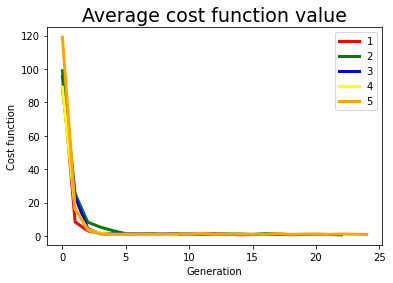

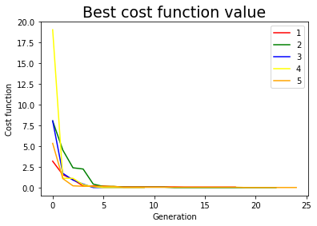

```
==========================

 1 : run of genetic algorithm with  100  chromosomes.

[[-0.13361263093373982, 1.7289416212117028], [1.0033406547882922, 1.1878595874264133], [0.7217237671168336, -2.1284769015704166], [-0.019997355029030738, -2.0034071094252974], [2.951499732971478, 3.1381159189046826], [0.5303335866630416, 2.096094690270798], [-1.338476790594497, 2.5532004203345986], …
Generation:  1  Average: 93.201  Curr best: 0.643 [X, Y] = 1.093 1.145
-------------------------
[[1.3125881394680197, 0.8814533276258645], [0.7693351466639701, 0.8434912675803099], [1.3652552934107645, 0.9745230173105778], [1.3672602286067228, 0.9858188351448803], [1.102690298747361, 1.1983354067445227], [1.1637550033044082, 1.1204686789160303], [1.349189997153701, 0.8840110345094856], [1.3491…
Generation:  2  Average: 6.811  Curr best: 0.032 [X, Y] = 0.985 0.910
-------------------------
[[0.9859401810205748, 0.881741824534189], [0.9859760975259204, 0.8809263467109947], [1.3560942252485775, 0.9229095001573584], [1.358351065315888, 0.9356245516627051], [1.268180031772383, 0.7635628998227382], [1.078723943555252, 0.8239140245746094], [1.0094966967514751, 1.1247961911029067], [1.014726…
Generation:  3  Average: 1.157  Curr best: 0.032 [X, Y] = 0.985 0.910
-------------------------
[[1.3073797853917741, 1.1853545435194683], [1.0354664931720325, 0.6512652401605113], [0.9872030794567481, 0.8530679416568498], [0.9872030794567481, 0.8530679416568498], [1.0799507890342266, 0.7908030697957487], [1.2938961865503462, 1.018937272023309], [0.9889186729096038, 0.8436643071104676], [1.006…
Generation:  4  Average: 1.116  Curr best: 0.032 [X, Y] = 0.985 0.910
-------------------------
[[1.0002540464989695, 0.9790894069432337], [0.9936391043919456, 0.9495114262087598], [1.1858458568745491, 0.7972188842417003], [1.1027965370072312, 0.725094392832514], [0.7476086860701879, 1.0396645551066446], [0.8878788581284071, 0.9172581359442298], [0.9777215129440753, 0.903161432496892], [0.9748…
Generation:  5  Average: 1.063  Curr best: 0.008 [X, Y] = 1.009 1.019
-------------------------
[[1.0047694209042057, 0.9992794033190451], [1.0068575231365053, 1.0086161211011992], [1.0033642389181012, 0.9819001852273179], [0.9921339572001362, 0.9102583834140621], [1.0085189807113069, 1.0968497175938996], [1.00857644566107, 1.0900815011083762], [0.9866392425150552, 0.8782950554707993], [0.9863…
Generation:  6  Average: 0.927  Curr best: 0.001 [X, Y] = 1.002 0.989
-------------------------

Solution found ! Chromosome content: [X, Y] = 1.002 0.989


 2 : run of genetic algorithm with  100  chromosomes.

[[-0.3598141513743787, 0.8456768944365718], [-0.5538447745720749, 1.281524871342404], [0.7899345075041437, 1.5024449646335776], [0.3637701990847462, 0.960230552444622], [0.7287169376041187, 3.783025848848917], [-1.0165557569622137, 1.115426171681361], [0.3387009306383931, 3.7203532937405783], [0.168…
Generation:  1  Average: 92.382  Curr best: 2.325 [X, Y] = 1.284 2.132
-------------------------
[[1.6027262402134694, 0.9872043789338966], [1.328822566552328, 0.5487642285705705], [1.0613813161161623, 0.5145653649395183], [1.184873887929308, 0.4800108043609827], [0.6644132287053415, 0.6973385789277184], [0.6644132287053415, 0.6973385789277184], [0.6896237156112204, 0.8075948236483861], [1.1564…
Generation:  2  Average: 4.541  Curr best: 0.279 [X, Y] = 0.975 0.539
-------------------------
[[0.6512094390040518, 1.0973335009717615], [0.6512094390040518, 1.0973335009717615], [0.9756834720321316, 1.1579011232631427], [0.9757535379029834, 1.1618426915865971], [0.9592446735880947, 0.981032239319393], [0.6644155581259978, 1.0923474209946193], [0.7317256247748478, 1.1578512171489825], [0.898…
Generation:  3  Average: 1.318  Curr best: 0.067 [X, Y] = 0.972 0.976
-------------------------
[[0.7435329523268029, 0.9382283020598667], [0.8830887354277683, 0.6977256410317727], [0.8208124684275249, 0.8704835456544797], [0.8056215867805852, 0.8908018786144065], [0.8256130850755841, 1.2284190740424334], [0.8045825711535419, 1.212612082436817], [0.6863341081818671, 1.1154869023550524], [0.932…
Generation:  4  Average: 1.179  Curr best: 0.067 [X, Y] = 0.972 0.976
-------------------------
```

[output cut: 77 more lines]

```
-------------------------
[[1.0231498226617584, 0.7784994456810169], [1.3323766366565926, 1.0892525733944953], [1.342112904577954, 1.0990368985949293], [1.342112904577954, 1.0990368985949293], [1.196820087896895, 0.6530531953409355], [1.089826940992483, 0.5712441324118339], [1.342112904577954, 1.0990368985949293], [1.3421129…
Generation:  3  Average: 1.223  Curr best: 0.122 [X, Y] = 1.013 0.769
-------------------------
[[1.035077234768319, 0.9648584251532473], [1.0174300652928436, 0.805080671116217], [1.2749876217735927, 0.9977417812936703], [1.051079614434083, 0.9587888829319119], [1.342112904577954, 1.0875815278368979], [1.342112904577954, 1.09213764031531], [0.986406142073081, 0.9280673089890241], [1.0132244363…
Generation:  4  Average: 1.135  Curr best: 0.015 [X, Y] = 0.989 1.058
-------------------------
[[0.997934848908488, 0.8779305260574214], [0.9971785593688537, 1.0048465547808902], [0.991209097070407, 1.07779664146396], [0.9942272160393266, 1.104548654317921], [0.994700484696535, 1.1087436145999368], [0.9907358284131987, 1.0736016811819444], [1.0311716129541928, 1.0241146107691628], [1.00438830…
Generation:  5  Average: 1.013  Curr best: 0.015 [X, Y] = 0.989 1.058
-------------------------
[[0.9964661768780125, 0.9516522664849836], [0.9964661768780125, 0.9516522664849836], [0.9964661768780125, 1.066495837173861], [0.9964661768780125, 1.009550792082837], [0.9964661768780125, 0.9516522664849836], [0.9964661768780125, 0.9516522664849836], [0.9937756055964707, 0.9945683224831281], [0.9921…
Generation:  6  Average: 1.009  Curr best: 0.001 [X, Y] = 0.997 1.020
-------------------------

Solution found ! Chromosome content: [X, Y] = 0.997 1.020
```

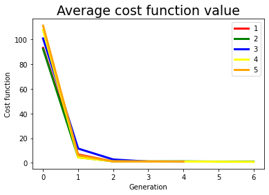

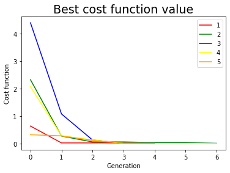

```
==========================

 1 : run of genetic algorithm with  150  chromosomes.

[[-1.2367324489153997, 1.1051472018796058], [-0.10808573795103743, -0.07689019108389661], [0.41578530572753536, -0.6255429773838621], [0.41578530572753536, -0.6255429773838621], [3.396074031962229, 1.7838191213696175], [3.407222505486966, 1.532838289831837], [0.49071566296068225, -0.5946429398032874…
Generation:  1  Average: 102.261  Curr best: 1.826 [X, Y] = 0.802 0.314
-------------------------
[[1.1958650331205027, 0.33819887628367173], [0.6494089827697543, 1.0717530888565547], [1.388894934471331, 0.9308959930755231], [0.835295248540617, 0.6211373485669345], [0.5868463665972401, 1.3438011236581011], [1.401048935869044, 0.6228807252990096], [1.1663031262731152, 0.6292922945581473], [1.2601…
Generation:  2  Average: 6.624  Curr best: 0.300 [X, Y] = 1.343 0.823
-------------------------
[[0.8592443854334919, 0.8870698633870804], [0.8293531123398612, 0.8372398152978134], [0.9872536579764812, 1.3013991287916926], [0.9539831344838396, 1.0425156478745405], [1.2165440187705188, 0.6888802369475349], [1.1215727859665656, 0.5816267195955522], [1.0244160184039226, 1.3073682262582174], [1.02…
Generation:  3  Average: 1.642  Curr best: 0.135 [X, Y] = 1.030 1.173
-------------------------
[[0.9917207184312877, 1.0838273191214156], [0.9906199161178534, 1.079383084504244], [0.9964382985914737, 1.102873457380126], [0.9964382985914737, 1.102873457380126], [1.0084150681679187, 0.9551132549947352], [1.003651705306561, 0.9853139623591065], [1.0052920936588539, 1.0354752002194147], [1.018107…
Generation:  4  Average: 1.037  Curr best: 0.005 [X, Y] = 0.994 1.044
-------------------------
[[1.0006509378866346, 1.0494384126624434], [0.9968668713677091, 0.9755771283327989], [0.9998869188296774, 1.034525506529071], [0.9976308904246661, 0.990490034466171], [1.0001883123866866, 0.9762059755932577], [0.9999933829994765, 0.9757384498617823], [0.999036479449219, 0.995578632485239], [1.000416…
Generation:  5  Average: 0.895  Curr best: 0.001 [X, Y] = 1.004 0.985
-------------------------

Solution found ! Chromosome content: [X, Y] = 1.004 0.985


 2 : run of genetic algorithm with  150  chromosomes.

[[-0.14157835017463838, 0.031430290962871116], [0.49254797953813223, -0.1036061178265203], [0.13865216120352286, 1.0956694046465008], [0.8218798960122138, 0.5497431424924444], [1.8152966401947834, 0.14254379536753153], [1.0070530478662372, 2.0848468583423068], [-0.06467501701760126, 0.70416191669070…
Generation:  1  Average: 106.636  Curr best: 4.065 [X, Y] = -0.466 0.920
-------------------------
[[1.1002868887419859, 1.2650385621125844], [1.1823260880706057, 1.2597934492693443], [1.071620551886112, 1.3400197118042207], [1.1722875663717596, 1.9759004138004101], [1.095096753481927, 1.2653703894016544], [1.1875162233306644, 1.2594616219802743], [0.554795166982585, 1.0020785557092546], [0.93457…
Generation:  2  Average: 5.783  Curr best: 0.320 [X, Y] = 0.682 0.658
-------------------------
[[0.9762884898951015, 1.0435147667807056], [1.0294652961641702, 1.1002616645696934], [1.0721584294630464, 1.091441158827514], [1.2989495210824349, 0.7527594328525927], [1.3291891959400841, 0.6848864631380442], [1.0595294817048728, 1.1095980521821918], [1.2861156695935405, 0.897067913081508], [1.0606…
Generation:  3  Average: 1.228  Curr best: 0.173 [X, Y] = 0.955 1.021
-------------------------
[[0.9818565762352651, 1.0123672719828585], [0.9944641169682846, 1.0409338728785205], [1.0055154232472379, 1.074703886925064], [0.9621159030323925, 1.0283906855405824], [1.2393080876614986, 1.0559355518711089], [1.108769963468523, 1.0712304854163175], [1.012797975652839, 1.0824753626115227], [1.01279…
Generation:  4  Average: 1.044  Curr best: 0.005 [X, Y] = 0.999 1.068
-------------------------
[[0.9960684892877021, 1.0470812320105813], [1.0008094006388648, 1.0652466443255009], [0.9968606589502292, 1.067959637430888], [0.9892659480410071, 1.0672094240675047], [0.996648038213924, 1.0529223808903598], [0.997249722481528, 1.0562252915045462], [0.9944641169682846, 1.0409338728785205], [0.99446…
Generation:  5  Average: 1.007  Curr best: 0.004 [X, Y] = 0.998 1.058
-------------------------
```

[output cut: 59 more lines]

```
-------------------------
[[0.5781154183511392, 0.7341169494444337], [0.47250989184276904, 0.8654894142206178], [0.2774443574140969, 1.0049686542103053], [0.08278575767310324, 0.7222643004507372], [0.2191970877754452, 0.8521140691715402], [0.10099330362024743, 0.7266377595937963], [0.281533256281933, 1.010906997101695], [0.0…
Generation:  2  Average: 6.124  Curr best: 0.302 [X, Y] = 1.336 0.678
-------------------------
[[0.9828629076184211, 0.9122665422419477], [0.7376611922077484, 0.6762971055532807], [0.6866139651075631, 0.6415809688332332], [0.6845895019442898, 0.6371009953583713], [1.0018643452521812, 0.9982630586395586], [1.0238965007688452, 0.9852245692576714], [1.3287101316632126, 0.6849797930691935], [1.05…
Generation:  3  Average: 1.608  Curr best: 0.035 [X, Y] = 0.980 1.011
-------------------------
[[1.004819160170064, 0.9672908238105686], [0.9962912344735819, 0.9275488046927406], [0.9805163477818484, 1.0090338318839729], [0.990539340201202, 0.9035919806980351], [0.9854980158155846, 0.9566266986153995], [0.9855576721674657, 0.9559991139666086], [1.2499458360763327, 0.9815147034428977], [1.0738…
Generation:  4  Average: 1.083  Curr best: 0.010 [X, Y] = 1.010 0.993
-------------------------
[[1.0057559462385162, 1.0393981960015246], [1.0091797444505226, 1.0052327974709678], [1.0024269097870184, 1.0719842721070072], [1.0050700390372103, 1.0458195309646707], [0.9938081131974169, 0.9159769105719999], [1.007302281446229, 0.9788627179313094], [0.6748507638625748, 0.998349827506572], [0.9704…
Generation:  5  Average: 0.951  Curr best: 0.005 [X, Y] = 1.005 1.051
-------------------------

Solution found ! Chromosome content: [X, Y] = 1.005 1.051
```

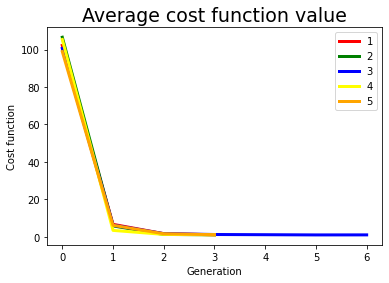

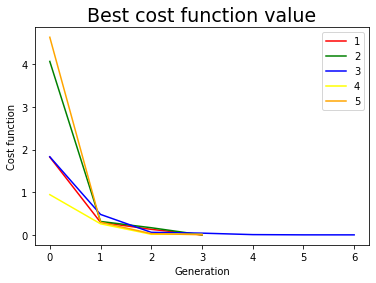

```python
number_of_chromosomes = [20, 100, 150]
all_avg_list = []
generations_list = []
all_best_list = []
run_number = 5

for x in number_of_chromosomes:

  print("==========================")

  for k in range(0, run_number):

    print("\n", k + 1, ": run of genetic algorithm with ", x ," chromosomes.\n")
    genetic(levy_function, [10, -10], x)

  display_stats(all_avg_list, all_best_list, generations_list)
  all_best_list = []
  all_avg_list = []
  generations_list = []
```